# Feiyaw__OriginalHomeworkCode_04

Feiya Wang

10/23/2019

## Homework 4

Introduction: This is the code for [Homework 04](https://fuzzyatelin.github.io/bioanth-stats/homework-04.html), on week 7 of AN597

# Question 1

> Write a simple R function, Z.prop.test(), that can perform one- or two-sample Z-tests for proportion data, using the following guidelines.

1.Your function should take the following arguments: p1 and n1 (no default) representing the estimated proportion and sample size (i.e., based on your sample data); p2 and n2 (both defaulting to NULL) that contain a second sample’s proportion and sample size data in the event of a two-sample test; p0 (no default) as the expected value for the population proportion; and alternative (default “two.sided”) and conf.level (default 0.95), to be used in the same way as in the function t.test().

2.When conducting a two-sample test, it should be p1 that is tested as being smaller or larger than p2 when alternative=“less” or alternative=“greater”, the same as in the use of x and y in the function t.test().

3.The function should perform a one-sample Z-test using p1, n1, and p0 if either p2 or n2 (or both) is NULL.

4.The function should contain a check for the rules of thumb we have talked about (n∗p>5 and n∗(1−p)>5) to ensure the validity of assuming the normal distribution in both the one- and two-sample settings. If this is violated, the function should still complete but it should also print an appropriate warning message.

5.The function should return a list containing the members Z (the test statistic), P (the appropriate p value), and CI (the two-sided CI with respect to “conf.level” around p1 in the case of a one-sample test and around p2-p1 in the case of a two-sample test). For all test alternatives (“two.sided”, “greater”, “less”), calculate symmetric CIs based on quantiles of the normal distribution rather than worrying about calculating single-limit confidence bounds.

```r
z.prop.test <-function(p1,n1,p2=NULL,n2=NULL,p0,alternative=c("two.sided", "less", "greater"),conf.level=0.95){
  #seeting function for allthe required default and no default values
  m=mean(p1)
  #mean of population one
  ste=sqrt(p0(1−p0)/n1)
  #standard error of population one.
  s=sd(p1)
  #standard deviation of p1
  a=1-conf.level
  # alpha value

  if(is.NULL(p2) | is.NULL(n2)){  # if p2 and n2 are null, we do the one-propotion z test.
      if(n1∗p0>5 & n1∗(1−p0)>5){    #check for rule of thumbs
        z=(m-p0)/ste
        # z-score calculation

        if(alternative=="less"){      # contain if(less), else if(greater), else if(two sided), else(error)
         p <- pnorm(z)
         # p value calculation

         lower <- m - qnorm(1 - a/2) * ste
         # (1-alpha)/2 each in the upper and lower tails of the distribution

         upper <- m + qnorm(1 - a/2) * ste
         # (1-alpha)/2 each in the upper and lower tails of the distribution

         ci <- c(lower, upper)
         # confidence interval

         test=TRUE
         #result of test as a boolean veriable.

           r=c(z,p,ci,test)
           # variable for return

           if(p< a){        # check if p value is less than alpha value.if(yes), else (no)


             return(r)
         }
           else{
          test=FALSE
          return(r)
          # cannot reject hypothesis because p value > alpha
        }
      }

        else if(alternative=="greater"){
          p <- 1-pnorm(z)
          # p value calculation

         lower <- m - qnorm(1 - a/2) * ste
         # (1-alpha)/2 each in the upper and lower tails of the distribution

         upper <- m + qnorm(1 - a/2) * ste
         # (1-alpha)/2 each in the upper and lower tails of the distribution

         ci <- c(lower, upper)
         # confidence interval

         test=TRUE
         #result of test as a boolean veriable.

           r=c(z,p,ci,test)
           # variable for return

           if(p< a){        # check if p value is less than alpha value.if(yes), else (no)


             return(r)
         }
           else{
          test=FALSE
          return(r)
          # cannot reject hypothesis because p value > alpha
        }
      }

        else if(alternative=="two.sided"){
          p <- 2*pnorm(z)
          #p value calculation

         lower <- m - qnorm(1 - a/2) * ste
         # (1-alpha)/2 each in the upper and lower tails of the distribution

         upper <- m + qnorm(1 - a/2) * ste
         # (1-alpha)/2 each in the upper and lower tails of the distribution

         ci <- c(lower, upper)
         # confidence interval

         test=TRUE
         #result of test as a boolean veriable.

           r=c(z,p,ci,test)
           # variable for return

           if(p< a){        # check if p value is less than alpha value.if(yes), else (no)


             return(r)
         }
           else{
          test=FALSE
          return(r)
          # cannot reject hypothesis because p value > alpha
        }
    }

        else { #error
       warning("it is a one-proptional z test")
      # error message
    }

      }
      else{     # cannot pass rule of thumbs
      warning("cannot assume this normal approximation since it didn't pass rule of thumb check")
      }
    }

  else if(!(is.null(p2)&is.null(n2))){  "if we have p2,n2 value, we should do two proption z test"
      m1=mean(p1)
      #mean of population one
      m2=mean(p2)
      #mean of population two
      p0=(sum(p1)+sum(p2))/(n1+n2)
      # define the pooled propotion
      ste=sqrt(p0*(1−p0)*(1/n1+1/n2))
      # standard error of p1+p2
      if(n1∗p0>5 & n1∗(1−p0)>5 & n2∗p0>5& n2∗(1-p0)>5){            #check for rule of thumbs
        z=(m1-m2)/ste
        # z-score for two propotion z test
        m= m1-m2
        #restate m.
        if(alternative=="less"){   # contain if(less), else if(greater), else if(two sided), else(error)
          p <- pnorm(z)
          # p value calculation


         lower <- m - qnorm(1 - a/2) * ste
         # (1-alpha)/2 each in the upper and lower tails of the distribution

         upper <- m + qnorm(1 - a/2) * ste
         # (1-alpha)/2 each in the upper and lower tails of the distribution

         ci <- c(lower, upper)
         # confidence interval

         test=TRUE
         #result of test as a boolean veriable.

           r=c(z,p,ci,test)
           # variable for return

           if(p< a){        # check if p value is less than alpha value.if(yes), else (no)


             return(r)
         }
           else{
          test=FALSE

          return(r)
          # cannot reject hypothesis because p value > alpha
        }
      }

        else if(alternative=="greater"){
            p <- 1-pnorm(z)
            # p value calculation

         lower <- m - qnorm(1 - a/2) * ste
         # (1-alpha)/2 each in the upper and lower tails of the distribution

         upper <- m + qnorm(1 - a/2) * ste
         # (1-alpha)/2 each in the upper and lower tails of the distribution

         ci <- c(lower, upper)
         # confidence interval

         test=TRUE
         #result of test as a boolean veriable.

           r=c(z,p,ci,test)
           # variable for return

           if(p< a){        # check if p value is less than alpha value.if(yes), else (no)


             return(r)
         }
           else{

              test=FALSE
          return(r)
          # cannot reject hypothesis because p value > alpha
        }
      }

        else if(alternative=="two.sided"){
          p <- 2*pnorm(z)
          # p value calculation

         lower <- m - qnorm(1 - a/2) * ste
         # (1-alpha)/2 each in the upper and lower tails of the distribution

         upper <- m + qnorm(1 - a/2) * ste
         # (1-alpha)/2 each in the upper and lower tails of the distribution

         ci <- c(lower, upper)
         # confidence interval

         test=TRUE
         #result of test as a boolean veriable.

           r=c(z,p,ci,test)
           # variable for return

           if(p< a){        # check if p value is less than alpha value.if(yes), else (no)


             return(r)
         }
           else{
          test=FALSE
          return(r)
          # cannot reject hypothesis because p value > alpha
        }
    }

        else { #error
       warning("it is a one-proptional z test")
      # error message
    }

      }
      else{    # cannot pass the check for rule of thumbs
        warning("cannot assume this normal approximation since it didn't pass rule of thumb check")
      }
    }

  else {
        warning("cannot assume this normal approximation since it didn't pass rule of thumb check")
    }
  }
```

# Question 2

> The dataset from Kamilar and Cooper has in it a large number of variables related to life history and body size. For this exercise, the end aim is to fit a simple linear regression model to predict longevity (MaxLongevity_m) measured in months from species’ brain size (Brain_Size_Species_Mean) measured in grams. Do the following for both longevity~brain size and log(longevity)~log(brain size):

```r
library (curl)
#install package curl before this step to load a file from server.
f <- curl("https://raw.githubusercontent.com/fuzzyatelin/fuzzyatelin.github.io/master/AN597_Fall19/KamilarAndCooperData.csv")
#load the file in varibale f
d <- read.csv(f, header = TRUE, sep = ",", stringsAsFactors = FALSE)
# read file in d as a dataframe.
```

> 1.Fit the regression model and, using {ggplot2}, produce a scatterplot with the fitted line superimposed upon the data. Append the the fitted model equation to your plot (HINT: use the function geom_text()).

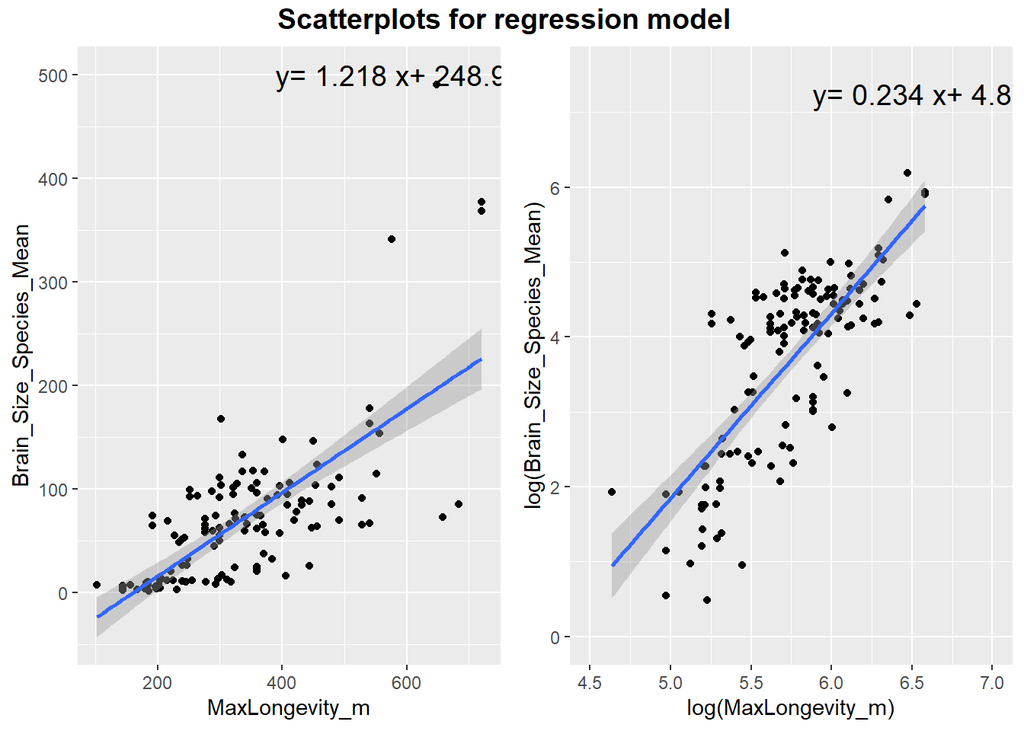

```r
library(ggplot2)
attach(d)

p1 <- ggplot(data=d, aes(x=MaxLongevity_m,y=Brain_Size_Species_Mean))
# build a ggplot object
p1 <- p1 + geom_point()
# make a scatterplot
p1 <- p1 + geom_smooth(method="lm", fullrange=TRUE)
# add a regression line
m1<-lm(data=d,MaxLongevity_m ~ Brain_Size_Species_Mean)
# make the model of two variable
t1 <- unlist(m1$coefficients)
# unlist m to get coeffient

beta0<-round(t1[1],digits = 3)
#round beta 1 to 3 decimal place

beta1<-round(t1[2],digits = 3)
#round beta 0 to 3 decimal place

soe1<-paste("y=",as.character(beta1),"x+",as.character(beta0))
#make the regression equation as a string

p1<-p1+annotate("text", label = soe1, x = 600, y = 500, size = 5, colour = "black")
#add it to the ggplot

#same method for log~log
p2 <- ggplot(data=d,aes(x=log(MaxLongevity_m),y=log(Brain_Size_Species_Mean)))
# build a ggplot object
p2 <- p2 + geom_point()+xlim(4.5,7)+ylim(0,7.5)
# make a scatterplot
p2 <- p2 + geom_smooth(method="lm")
# add a regression line
m2<-lm(data=d,log(MaxLongevity_m) ~ log(Brain_Size_Species_Mean))
# make the model of two variable
t2 <- unlist(m2$coefficients)
# unlist m to get coeffient
beta00<-round(t2[1],digits = 3)
#round beta 1 to 3 decimal place
beta11<-round(t2[2],digits = 3)
#round beta 0 to 3 decimal place
soe2<-paste("y=",as.character(beta11),"x+",as.character(beta00))
#make the regression equation as a string
p2<-p2+annotate("text", label = soe2, x = 6.6, y = 7.25, size = 5, colour = "black")
#addd it to ggplot

library(ggpubr)
figure1 <- ggarrange(p1,p2,
                    ncol = 2, nrow = 1)
# use this unction to combine 2 ggplot into one figure and label it to make it look nice

annotate_figure(
  figure1,
  top = text_grob("Scatterplots for regression model  ",
                  color = "black", face = "bold", size = 14)
  )
```

```r
detach(d)
```

> 2.Identify and interpret the point estimate of the slope (β1), as well as the outcome of the test associated with the hypotheses H0: β1 = 0; HA: β1 ≠ 0. Also, find a 90 percent CI for the slope (β1) parameter.

For regression model of longevity (MaxLongevity_m)from species’ brain size (Brain_Size_Species_Mean):

```r
t1 <- coef(summary(m1))
#summary of m1 we use as the regression model
t1 <- data.frame(unlist(t1))
#unlist it
colnames(t1) <- c("Est", "SE", "t", "p")
#name the columns. find t and p
t1$p[2]
```

```
## [1] 2.685909e-20
```

```r
#show the p values of t test for slope(beta1) only
```

Since p<0.05, we reject the null hypothesis. Which means that beta 1 is not equal to zero.

For 90% confident interval:

```r
ci1 <- confint(m1, level = 0.90)
#confident interval in m1
ci1[2,]
```

```
##      5 %     95 %
## 1.035571 1.400410
```

```r
#show only beta1 confident interval.
```

For regression model of log of longevity [log(MaxLongevity_m)]from log of species’ brain size [log(Brain_Size_Species_Mean)]:

```r
t2 <- coef(summary(m2))
#summary of m1 we use as the regression model
t2 <- data.frame(unlist(t2))
#unlist it
colnames(t2) <- c("Est", "SE", "t", "p")
#name the columns. find t and p
t2$p[2]
```

```
## [1] 2.165214e-25
```

```r
#show the p values of t test for slope(beta1) only
```

Since p<0.05, we reject the null hypothesis. Which means that beta 1 is not equal to zero.

For 90% confident interval:

```r
ci2 <- confint(m2, level = 0.90)
#confident interval in m1
ci2[2,]
```

```
##       5 %      95 %
## 0.2046396 0.2636595
```

```r
#show only beta1 confident interval.
```

> 3.Using your model, add lines for the 90 percent confidence and prediction interval bands on the plot and add a legend to differentiate between the lines.

```r
ci_1 <- predict(m1, newdata = data.frame(Brain_Size_Species_Mean = d$Brain_Size_Species_Mean), interval = "confidence",
    level = 0.90)
pi_1 <- predict(m1, newdata = data.frame(Brain_Size_Species_Mean = d$Brain_Size_Species_Mean), interval = "prediction",
    level = 0.90)
df <- data.frame(cbind(d$MaxLongevity_m, d$Brain_Size_Species_Mean, ci_1,pi_1))
names(df) <- c("x", "y", "CIfit", "CIlwr", "CIupr","PIfit", "PIlwr", "PIupr")
head(df)
```

```
##       x     y    CIfit    CIlwr    CIupr    PIfit    PIlwr    PIupr
## 1 276.0 58.02 319.6201 306.1354 333.1047 319.6201 168.3750 470.8651
## 2    NA    NA       NA       NA       NA       NA       NA       NA
## 3    NA 52.84 313.3109 299.6449 326.9768 313.3109 162.0496 464.5722
## 4 243.6 52.63 313.0551 299.3805 326.7297 313.0551 161.7930 464.3172
## 5    NA 51.70 311.9224 298.2081 325.6366 311.9224 160.6567 463.1880
## 6 300.0 49.88 309.7056 295.9081 323.5032 309.7056 158.4324 460.9789
```

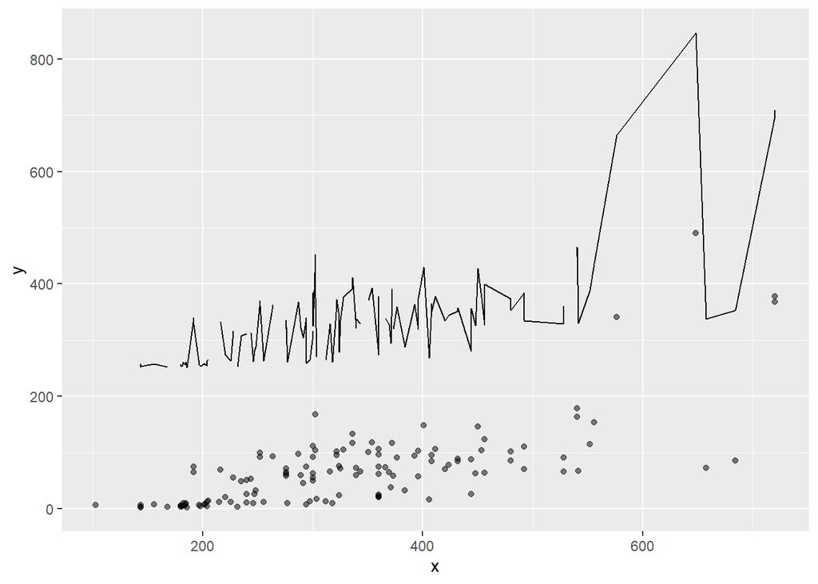

```r
g1 <- ggplot(data = df, aes(x = x, y = y))
g1 <- g1 + geom_point(alpha = 1/2)
g1 <- g1 + geom_line(aes(x = x, y = CIfit), colour = "black")
g1
```

```r
ci_2 <- predict(m2, newdata = data.frame(Brain_Size_Species_Mean = log(d$Brain_Size_Species_Mean)), interval = "confidence", level = 0.90)
pi_2 <- predict(m2, newdata = data.frame(Brain_Size_Species_Mean = log(d$Brain_Size_Species_Mean)), interval = "prediction", level = 0.90)
df_2 <- data.frame(cbind(log(d$MaxLongevity_m), log(d$Brain_Size_Species_Mean), ci_2,pi_2))
names(df_2) <- c("x", "y", "CIfit", "CIlwr", "CIupr","PIfit", "PIlwr", "PIupr")
head(df_2)
```

```
##          x        y    CIfit    CIlwr    CIupr    PIfit    PIlwr    PIupr
## 1 5.620401 4.060788 5.207083 5.130694 5.283471 5.207083 4.788356 5.625810
## 2       NA       NA       NA       NA       NA       NA       NA       NA
## 3       NA 3.967268 5.201627 5.124633 5.278621 5.201627 4.782789 5.620465
## 4 5.495528 3.963286 5.201392 5.124372 5.278412 5.201392 4.782549 5.620235
## 5       NA 3.945458 5.200336 5.123199 5.277474 5.200336 4.781472 5.619201
## 6 5.703782 3.909620 5.198200 5.120825 5.275575 5.198200 4.779292 5.617108
```

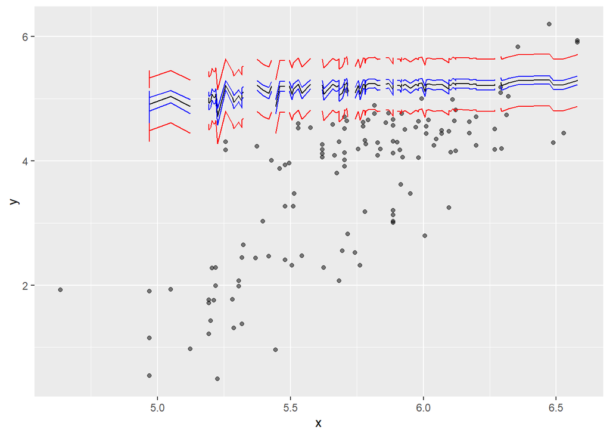

```r
g2 <- ggplot(data = df_2, aes(x = x, y = y))
g2 <- g2 + geom_point(alpha = 1/2)
g2 <- g2 + geom_line(aes(x = x, y = CIfit), colour = "black")
g2 <- g2 + geom_line(aes(x = x, y = CIlwr), colour = "blue")
g2 <- g2 + geom_line(aes(x = x, y = CIupr), colour = "blue")
g2 <- g2 + geom_line(data = df_2, aes(x = x, y = PIlwr), colour = "red")
g2 <- g2 + geom_line(data = df_2, aes(x = x, y = PIupr), colour = "red")
g2
```

Don’t know why, but raph looks wired.

> 4.Produce a point estimate and associated 90 percent PI for the longevity of a species whose brain weight is 800 gm. Do you trust the model to predict observations accurately for this value of the explanatory variable? Why or why not? Looking at your two models, which do you think is better? Why?